# Prediction Analysis (Logistic Regression)

*Author:* **Cisco EDS**

*Created:* July 18, 2016

## Overview

The predictive model will publish a risk score that is categorized into low, medium and high buckets. The risk score signifies the probability of issuing an RMA that is avoidable. The main objective behind this is to enable the TAC engineer to be more proactive in identifying and dealing with a case where there is a high chance of issuing the wrong RMA.

Model includes various static & dynamic variables to predict risk score.Static variables are more relevant at the SR Creation time whereas the dynamic variables get populated during the SR journey.

For the analysis we have considered the following conditions:

1. Time Period = FY15 and FY16
2. Incident Type = TAC Cases
3. Only Order lines (without Cancelled and Undispatched orders) has been considered
4. Only Closed Cases have been considered
5. % avoidability of cases (with or without RMA) is 7.7%

## Analysis

### Import libraries

```python
import numpy as np
import pickle
import pandas as pd
import statsmodels.api as sm
import matplotlib.pyplot as plt
%matplotlib inline
from patsy import dmatrices
from sklearn.linear_model import LogisticRegression
import seaborn as sns
import matplotlib.pyplot as plt
from patsy import dmatrices
from sklearn import metrics
from IPython.display import HTML, display
from sklearn.cross_validation import KFold
from sklearn.metrics import confusion_matrix
from sklearn import metrics
from ggplot import *
sns.set(style="whitegrid")
```

## Data Transformation

### Loading the DataSet

The dataset consists of 250,536 closed cases over the past two financial years for the UCS product family. ~87k cases out of these have atleast one RMA. These cases have been tagged as avoidable or non-avoidable by Fuzzy, RT and rules. The remaining cases that have no RMA issued are considered as non-avoidable for the training dataset. Intuition behind this being, the model has to learn and should be able to publish a low risk score to these kind of cases where there was no RMA issued.

```python
ADS = pd.read_csv("pm_0825.csv", low_memory=False)
TestData  = pd.read_csv("example.csv")
```

#### Clean the ARMA column

Changing all the NAs in the 'avoidability' column to '0's. These NAs are the cases which have no RMA and since we are considering these cases as non-avoidable, we will have to modify the arma column.

```python
ADS = ADS[ADS['closed_date'] != 'null']
df = ADS.copy()
df.arma = df.arma.fillna(0)
dft = TestData.copy()
```

#### Modules

Making the code modular so that there is no redudant code anywhere in the analysis. Since this analysis is done on almost ~45 variables, there is bound to be a lot of code that is pretty common across all the variables specially in regards to the univariate and bivariate analysis and plotting graphs. Also the idea is to make it very generic so that addition of variables will be easier.

```python
class Categorical():
    def __init__(self,data,testdata):
        self.data = data
        self.testdata = testdata
        self.var = list()

    def Bivariate(self,variable):
        self.df = pd.DataFrame()
        self.data[variable] = self.data[variable].fillna('Unknown')
        self.df = pd.crosstab(self.data[variable],self.data.arma.astype(bool))
        self.df.rename(columns={False : 'NonAvoidable', True : 'Avoidable', 'All' : 'Total'}, inplace=True)
        self.df['%avoidability'] = ((self.df['Avoidable'])/(self.df['NonAvoidable'] + self.df['Avoidable']))*100
        self.df['%avoidability'] = self.df['%avoidability'].round(1)
        self.df['Total']=100
        self.df['Total_cases'] = self.df['NonAvoidable'] + self.df['Avoidable']
        self.df['Total_cases']
        self.df['% Cases'] = self.df['Total_cases']/244294
        self.df['% Cases'] = self.df['% Cases'].round(2)
        self.df = self.df.sort_values(by = '%avoidability',ascending= False ,axis = 0)
        self.df = self.df.reset_index()
        self.df.index.names = ['index']
        print(self.df[[variable,'Total_cases','% Cases','Avoidable','%avoidability']].head(10))

    def BivariateNP(self,variable):
        self.df = pd.DataFrame()
        self.data[variable] = self.data[variable].fillna('Unknown')
        self.df = pd.crosstab(self.data[variable],self.data.arma.astype(bool))
        self.df.rename(columns={False : 'NonAvoidable', True : 'Avoidable', 'All' : 'Total'}, inplace=True)
        self.df['%avoidability'] = ((self.df['Avoidable'])/(self.df['NonAvoidable'] + self.df['Avoidable']))*100
        self.df['%avoidability'] = self.df['%avoidability'].round(1)
        self.df['Total']=100
        self.df['Total_cases'] = self.df['NonAvoidable'] + self.df['Avoidable']
        self.df['% Cases'] = self.df['Total_cases']/2442.94
        self.df['% Cases'] = self.df['% Cases'].round(2)
        self.df = self.df.sort_values(by = '%avoidability',ascending= False ,axis = 0)
        self.df = self.df.reset_index()
        self.df.index.names = ['index']

    def Bivariate2(self,variable):
        self.df = pd.DataFrame()
        self.data[variable] = self.data[variable].fillna('Unknown')
        self.df = pd.crosstab(self.data[variable],self.data.arma.astype(bool))
        self.df.rename(columns={False : 'NonAvoidable', True : 'Avoidable', 'All' : 'Total'}, inplace=True)
        self.df['%avoidability'] = ((self.df['Avoidable'])/(self.df['NonAvoidable'] + self.df['Avoidable']))*100
        self.df['%avoidability'] = self.df['%avoidability'].round(1)
        self.df['Total']=100
        self.df['Total_cases'] = self.df['NonAvoidable'] + self.df['Avoidable']
        self.df['% Cases'] = self.df['Total_cases']/2442.94
        self.df['% Cases'] = self.df['% Cases'].round(2)
        self.df = self.df.sort_values(by = 'Total_cases',ascending= False ,axis = 0)
        self.df = self.df.reset_index()
        print (self.df[[variable,'Total_cases','% Cases','Avoidable','%avoidability']].head(20))


    def changetocat(self,variable):
        self.df[variable] = self.df[variable].astype('category')

    def Graph(self,variable):
        self.var.append(variable)
        f, ax = plt.subplots(figsize=(10, 5))
        sns.set_color_codes("pastel")
        sns.barplot(x="Total", y=variable, data=self.df, color="b")
        sns.set_color_codes("muted")
        sns.barplot(x="%avoidability", y=variable, data=self.df,label="avoidability", color="b")

        # Add a legend and informative axis label
        ax.legend(ncol=2, loc="lower right", frameon=True)
        ax.set(xlim=(0, 100), ylabel="", xlabel="percentage")
        sns.despine(left=True, bottom=True)


    def Bucketing(self,variable):
        bins = [0,5,9,13,17,21,25,29,33,37,41,45,49,53,57,61,65,69,73,77,81,85,89,93,97,100]
        levels = ['_level0','_level1','_level2','_level3','_level4','_level5','_level6','_level7','_level8','_level9','_level10','_level11','_level12',
         '_level13','_level14','_level15','_level16','_level17','_level18','_level19','_level20','_level21','_level22','_level23','_level24',
         '_level25','_level26']

        self.df['capturemap'] = pd.cut(self.df['%avoidability'],bins,include_lowest = True)
        self.mapping = pd.Series(self.df['capturemap'].values,index=self.df[variable]).to_dict()

        self.df[variable] = pd.cut(self.df['%avoidability'],bins,include_lowest = True)

        self.maps = dict(zip(list(self.df[variable].unique()),levels))

        self.df[variable] = self.df[variable].astype('object')

        self.df[variable] = self.df[variable].map(lambda x: variable + self.maps[x])

        self.df = self.df.groupby(variable).sum()[['NonAvoidable','Avoidable']].reset_index()
        self.df['%avoidability'] = ((self.df['Avoidable'])/(self.df['NonAvoidable'] + self.df['Avoidable']))*100
        self.df['%avoidability'] = self.df['%avoidability'].round(1)
        self.df['Total'] = 100
        self.df[variable] = self.df[variable].astype('category')

    def MasterSetbucketing(self,variable):
        self.data[variable] = self.data[variable].map(lambda x: variable + self.maps[self.mapping[x]])

    def TestSetbucketing(self,variable):
        self.testdata[variable] = self.testdata[variable].map(lambda x: variable + self.maps[self.mapping[x]])

    def Gettestdata(self):
        return self.testdata

    def Dummyvalues(self, variable):
        pd.get_dummies(self.df)
        pd.get_dummies(self.df).columns

    def Getdata(self):
        return self.data

    def Getvariables(self):
        return self.var

    def Collinearity(self):
        pass
```

### Missing Value and Outlier Treatment

1. Categorical Variables: All the missing values have been replaced by 'Unknown'. Outlier Treatment is not required for the categorical variables
2. Continuous Variables : We do not have missing values for any of the continuous variables. All the records above x percentile are removed as a result of the outlier treatment

### Bucketing

There are various categorical variables (Customer Name, Country, Customer_vertical, Customer_Market_segment, etc) wih more than 100 levels. We need to reduce the # of levels by bucketing them based on the response rate (% avoidability). The reason behind reducing the levels is to avoid overfitting of the model and also make the process of flushing out the insignificant variables easier.

Bucketing is done on the basis of frequency(% Cases) and the response rate(% Avoidability). If the response rate for the fields is similar across the fields with %Cases < 5%, they can be grouped as into a single field

### Univariate and Bivariate Analysis

```python
variable = Categorical(df,dft);va = []
```

#### Var 1 : Entry Channel (Static)

- *Description* : Channel through which the customer raised the SR
- *Hypothesis* : There is a higher risk of cases having Avoidable RMA if the entry channel used to raise the request is 'Automatic'
- *Findings* :
  - Cases raised through Automatic channel have highest % avoidability(14.9%) which is 92% more than the avg %avoidability(7.7%)
  - 93% of the cases were raised through 'Web' channel

##### Missing value check & Bi variate analysis

```
True    244294
Name: entry_channel, dtype: int64
```

```
arma  entry_channel  Total_cases  % Cases  Avoidable  %avoidability
index
0         AUTOMATIC         3173     0.01        473           14.9
1               WEB       227754     0.93      17387            7.6
2             PHONE        11527     0.05        594            5.2
3             EMAIL         1840     0.01         26            1.4
```

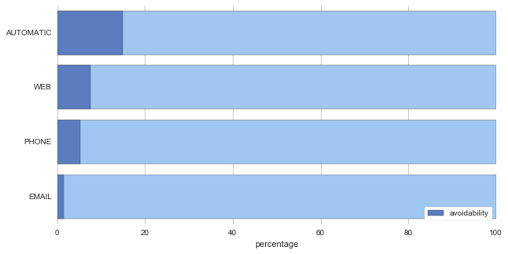

```python
display(df['entry_channel'].notnull().value_counts())
variable.Bivariate('entry_channel')
variable.Graph('entry_channel')
```

#### Var 2 : Initial Severity (static)

- *Description* : The severity with which the case was raised. Maximum severity is '1' and minimum severity will be '4'
- *Hypothesis* : There is a higher risk of cases having Avoidable RMA if the initial severity is high'
- *Findings* :
  - Cases raised with maximum severity '1' have highest %avoidability(8.7%)
  - 85% of the cases are raised with the severity '3'

##### Missing value check & Bi variate analysis

```
True    244294
Name: initial_severity, dtype: int64
```

```
arma   initial_severity  Total_cases  % Cases  Avoidable  %avoidability
index
0                     1         8801     0.04        768            8.7
1                     2        14141     0.06       1081            7.6
2                     3       207842     0.85      15849            7.6
3                     4        13510     0.06        782            5.8
```

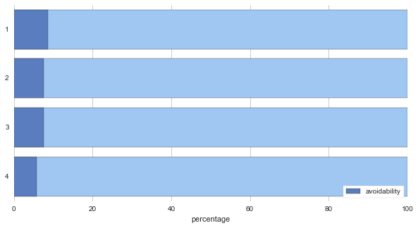

```python
display(df['initial_severity'].notnull().value_counts())
variable.Bivariate('initial_severity')
variable.changetocat('initial_severity')
variable.Graph('initial_severity')
```

#### Var 3 : Initial Problem Code (static)

##### Missing value check & Bi variate analysis

```
True    244294
Name: initial_problem_code, dtype: int64
```

```
arma  initial_problem_code  Total_cases  % Cases  Avoidable  %avoidability
index
0             HARDWARE_DOA          613     0.00        101           16.5
1         HARDWARE_FAILURE        87677     0.36      11991           13.7
2           ERROR_MESSAGES        55461     0.23       3200            5.8
3         SOFTWARE_FAILURE        16013     0.07        627            3.9
4        CONFIG_ASSISTANCE        54185     0.22       1944            3.6
5                  INTEROP        13820     0.06        476            3.4
6          DATA_CORRUPTION          455     0.00         11            2.4
7      INSTLL_UNSTLL_UPGRD         5396     0.02        107            2.0
8      SOFTWARE_ASSISTANCE         1357     0.01         10            0.7
9           PASSWORD_RECOV          306     0.00          1            0.3
```

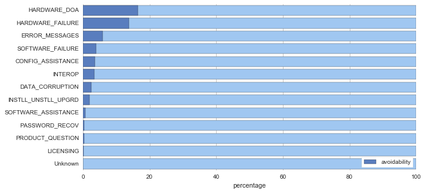

```python
display(df['initial_problem_code'].notnull().value_counts())
variable.Bivariate('initial_problem_code')
variable.Graph('initial_problem_code')
```

#### Var 4 : Request type (static)

##### Missing value check & Bi variate analysis

```
True    244294
Name: request_type, dtype: int64
```

```
arma                  request_type  Total_cases  % Cases  Avoidable  \
index
0               Replace my Product        36814     0.15       5111
1                          Unknown        39321     0.16       2863
2      Diagnose and Fix my Problem       160490     0.66      10462
3               Answer my Question         7669     0.03         44

arma   %avoidability
index
0               13.9
1                7.3
2                6.5
3                0.6
```

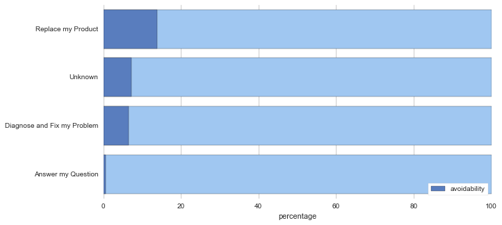

```python
display(df['request_type'].notnull().value_counts())
variable.Bivariate('request_type')
variable.Graph('request_type')
```

#### Var 5 : Entitlement Type(Static)

##### Missing value check & Bi variate analysis

```
True    244294
Name: entitlement_type, dtype: int64
```

```
arma                                    entitlement_type  Total_cases  \
index
0              Licensing Registration Completed by Agent         8344
1                                      Return and Repair          140
2                     Expedited Same Day Delivery and FE       199836
3                                         Field Engineer         1744
4      RMA service level associated with the product'...        34230

arma   % Cases  Avoidable  %avoidability
index
0         0.03       1150           13.8
1         0.00         12            8.6
2         0.82      14936            7.5
3         0.01        120            6.9
4         0.14       2262            6.6
```

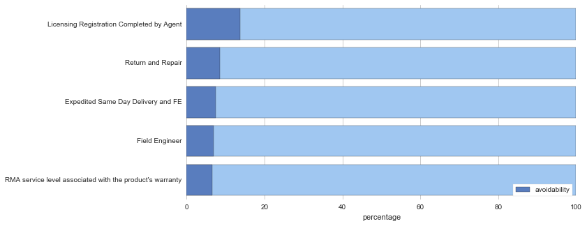

```python
display(df['entitlement_type'].notnull().value_counts())
variable.Bivariate('entitlement_type')
variable.Graph('entitlement_type')
```

#### Var 6: Customer Name

- *Description* : The name of the Customer who raised the request;bucketing has been done for this variable based on the response rate .i.e customers with similar % avoidability will fall under same bucket. Bucket Levels are described above
- *Hypothesis* : Customers with a large install base like JP Morgan will have higher risk of having cases with avoidable RMAs.
- *Findings* :
  - JP Morgan has highest %avoidability(20.6%)
  - The total number cases raised by JP Morgan is 2nd highest(1%) given that ~17% of the cases are not assigned to any customer

##### Missing value check & Bi variate analysis

```
True    244294
Name: Customer_name, dtype: int64
```

```
Top 20 Customer Name(measured in Total cases raised)
arma                                 Customer_name  Total_cases  % Cases  \
0                   C3 TO BE ASSIGNED CPR COMPANY         24825    10.16
1                                            NULL         16213     6.64
2     CISCO IT INTERNAL GLOBAL PRODUCTION NETWORK          2702     1.11
3                            JP MORGAN CHASE BANK          2475     1.01
4     CISCO TECHNICAL SERVICES PRODUCT MANAGEMENT          2207     0.90
5                                VCE  COMPANY LLC          1558     0.64
6                          KOHL'S DEPT STORES INC           909     0.37
7                DIMENSION DATA AUSTRALIA PTY LTD           801     0.33
8                     VERIZON BUSINESS PURCHASING           657     0.27
9                                   COMCAST CABLE           598     0.24
10                                EMC CORPORATION           579     0.24
11                            TELSTRA CORPORATION           453     0.19
12                                  CISCO SYSTEMS           438     0.18
```

[output cut: 29 more lines]

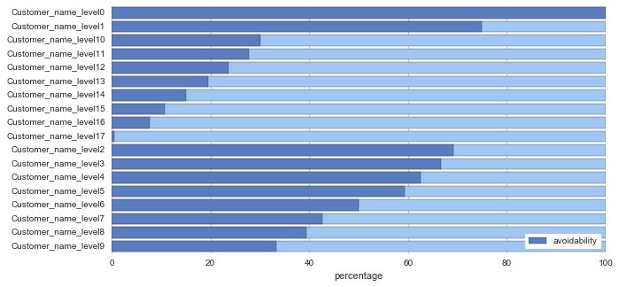

```python
display(df['Customer_name'].notnull().value_counts())
print ('Top 20 Customer Name(measured in Total cases raised) ')
variable.Bivariate2('Customer_name')
variable.BivariateNP('Customer_name')
variable.Bucketing('Customer_name')
variable.Graph('Customer_name')
variable.MasterSetbucketing('Customer_name')
variable.TestSetbucketing('Customer_name')
```

#### Var 7: Customer Vertical(Static)

- *Description* : The vertical/Industry of the customer who raised the SR. Bucketing has been done for this variable based on the response rate .i.e verticals with similar % avoidability will fall under same bucket. Bucket Levels are described above
- *Hypothesis* :
- *Findings* :
  - % Avoidability across the Top 20 Customer verticals(by Total cases raised)is close to avg %Avoidability(7.7%)
  - Maximum cases are raised from the customer vertical 'TS_OT'(~11%)

##### Missing value check & Bi variate analysis

```
True     228080
False     16214
Name: customer_vertical, dtype: int64
```

```
Top 20 Customer Verticals(measured in Total cases raised)
arma customer_vertical  Total_cases  % Cases  Avoidable  %avoidability
0                 UNKN        30286    12.40       2710            8.9
1                TS_OT        25865    10.59       1926            7.4
2              HI_TECH        16533     6.77       1473            8.9
3              Unknown        16214     6.64       1272            7.8
4                 PVDR        11388     4.66        797            7.0
5                  BNK        11149     4.56       1085            9.7
6            WHSL/DIST         9852     4.03        708            7.2
7                SP_OT         8895     3.64        584            6.6
8                RE_OT         7456     3.05        615            8.2
9          PROF_SRV_OT         6665     2.73        491            7.4
10                 INS         5667     2.32        361            6.4
11               TER 4         5667     2.32        362            6.4
12          FIN_SRV_OT         5609     2.30        423            7.5
13      CONSLT_NONTECH         4891     2.00        355            7.3
14             MOB_WIR         4624     1.89        346            7.5
15                 INC         4409     1.80        295            6.7
16               CABLE         4073     1.67        435           10.7
17           MCHRY/IND         3816     1.56        223            5.8
18             LOC/MUN         3639     1.49        182            5.0
19             CON_SER         3165     1.30        227            7.2
```

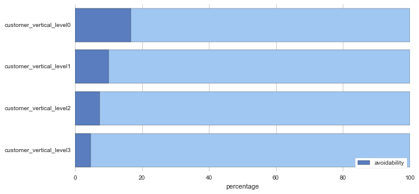

```python
display(df['customer_vertical'].notnull().value_counts())
print ('Top 20 Customer Verticals(measured in Total cases raised) ')
variable.Bivariate2('customer_vertical')
variable.BivariateNP('customer_vertical')
variable.Bucketing('customer_vertical')
variable.Graph('customer_vertical')
variable.MasterSetbucketing('customer_vertical')
variable.TestSetbucketing('customer_vertical')
```

#### Var 8: Customer Market Segment

- *Description* : Market segment of the customer
- *Hypothesis* : Banking and Service Providers will have a higher likelihood of avoidable RMAs given the sensitivity of their business to UCS products
- *Findings* : %Avoidability is consistent across all the market segments

##### Missing value check & Bi variate analysis

```
True     228080
False     16214
Name: customer_market_segment, dtype: int64
```

```
arma  customer_market_segment  Total_cases  % Cases  Avoidable  %avoidability
index
0                     UNKNOWN          768     0.00         67            8.7
1                          SP        29716     0.12       2341            7.9
2                     Unknown        16214     0.07       1272            7.8
3                         ENT       111065     0.45       8401            7.6
4                         COM        86531     0.35       6399            7.4
```

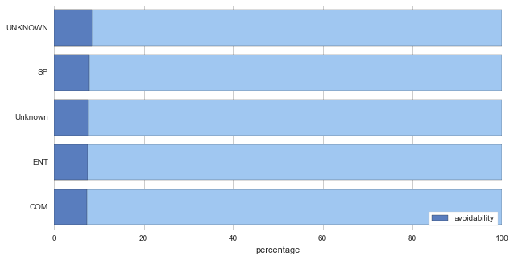

```python
display(df['customer_market_segment'].notnull().value_counts())
variable.Bivariate('customer_market_segment')
variable.Graph('customer_market_segment')
```

#### Var 9: Customer Geography

##### Missing value check & Bi variate analysis

```
True     228073
False     16221
Name: country, dtype: int64
```

```
Top 20 Country(measured in Total cases raised)
arma  country  Total_cases  % Cases  Avoidable  %avoidability
0          US       121619    49.78       9056            7.4
1         UNK        24830    10.16       2234            9.0
2     Unknown        16221     6.64       1273            7.8
3          GB         7870     3.22        641            8.1
4          CA         7835     3.21        519            6.6
5          AU         7737     3.17        527            6.8
6          IN         5278     2.16        403            7.6
7          DE         4886     2.00        444            9.1
8          JP         4483     1.84        208            4.6
9          CN         4106     1.68        344            8.4
10         FR         2303     0.94        148            6.4
11         BR         2250     0.92        180            8.0
12         NL         2099     0.86        185            8.8
13         ES         1980     0.81        140            7.1
14         SG         1918     0.79        126            6.6
15         MX         1884     0.77         82            4.4
16         CH         1483     0.61        106            7.1
17         IT         1449     0.59        111            7.7
18         KR         1444     0.59        109            7.5
19         HK         1160     0.47         89            7.7
```

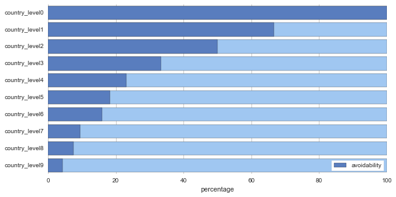

```python
display(df['country'].notnull().value_counts())
print('Top 20 Country(measured in Total cases raised)')
variable.Bivariate2('country')
variable.BivariateNP('country')
variable.Bucketing('country')
variable.Graph('country')
variable.MasterSetbucketing('country')
variable.TestSetbucketing('country')
```

#### Var 10: Contract Type(Static)

- *Description* : Contract type which the customer purchases; bucketing has been done for this variable based on the response rate .i.e countries with similar % avoidability will fall under same bucket. Bucket Levels are described above
- *Hypothesis* :
- *Findings* :
  - For Contract type 'SNTC 24X7X4OS', both the # Cases raised and the % Avoidability is high
  - ~60% of the cases are raised with Contract type 'SNTC'

##### Missing value check & Bi variate analysis

```
True     213147
False     31147
Name: contract_type, dtype: int64
```

```
Top 20 Contract Type(measured in Total cases raised)
arma                               contract_type  Total_cases  % Cases  \
0                                  SNTC 24X7X4OS        47759    19.55
1                                    SNTC 24X7X4        46355    18.98
2                                   SNTC 8X5XNBD        40916    16.75
3                                        Unknown        31147    12.75
4                                   Essential SW         6705     2.74
5                            UC SUPPORT 24x7x4OS         5205     2.13
6                                  SWSS UPGRADES         4172     1.71
7                                      TAC 2 TAC         3803     1.56
8                                 SNTC 8X5XNBDOS         3543     1.45
9                            UC ISV L1 + L2 24x7         3065     1.25
10                           UCS SUPP PSS 24X7X4         2793     1.14
11                           UC SUPP DR 24X7X4OS         2686     1.10
12                          UCS SUPP PSS 8X5XNBD         2237     0.92
```

[output cut: 29 more lines]

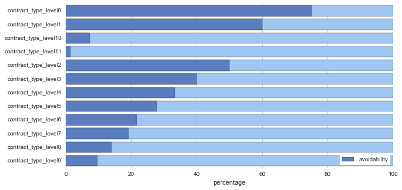

```python
display(df['contract_type'].notnull().value_counts())
print('Top 20 Contract Type(measured in Total cases raised)')
variable.Bivariate2('contract_type')
variable.BivariateNP('contract_type')
variable.Bucketing('contract_type')
variable.Graph('contract_type')
variable.MasterSetbucketing('contract_type')
variable.TestSetbucketing('contract_type')
```

#### Var 11: Product Family

##### Missing value check & Bi variate analysis

```
True    244294
Name: product_family, dtype: int64
```

```
arma  product_family  Total_cases  % Cases  Avoidable  %avoidability
index
0              UCSME           53     0.00          5            9.4
1               UCSB        98103     0.40       8331            8.5
2                UCS        23918     0.10       1981            8.3
3               UCSC        71549     0.29       5025            7.0
4               UCSX        41836     0.17       2810            6.7
5               UCSW         1366     0.01         73            5.3
6               UCSV         6215     0.03        255            4.1
7               UCSM         1254     0.01          0            0.0
```

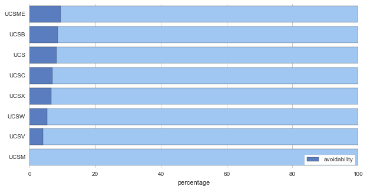

```python
display(df['product_family'].notnull().value_counts())
variable.Bivariate('product_family')
variable.Graph('product_family')
```

#### Var 12: Product Type

##### Missing value check & Bi variate analysis

```
True     210616
False     33678
Name: product_type, dtype: int64
```

```
arma  product_type  Total_cases  % Cases  Avoidable  %avoidability
index
0           MEMORY         6096     0.02        844           13.8
1            BOARD         2793     0.01        358           12.8
2           SERVER       123770     0.51      11565            9.3
3            POWER         4639     0.02        420            9.1
4          DEVICES        22423     0.09       1653            7.4
5        FUNCSYSTM        10104     0.04        704            7.0
6          CHASSIS         4772     0.02        321            6.7
7         ASSEMBLY         9924     0.04        635            6.4
8           SWITCH        20626     0.08       1028            5.0
9        ACCESSORY         4496     0.02        212            4.7
```

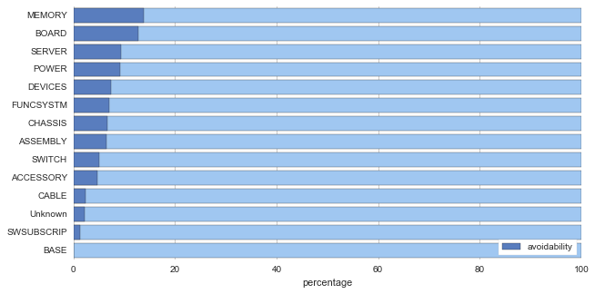

```python
display(df['product_type'].notnull().value_counts())
variable.Bivariate('product_type')
variable.Graph('product_type')
```

#### Var 13: SR_PID(Static)

- *Description* : The product for which the SR is raised. Bucketing has been done for this variable based on the response rate .i.e countries with similar % avoidability will fall under same bucket. Bucket Levels are described above
- *Hypothesis* : There is a higher risk of cases having avoidable RMAs if the SR_PID is 'UCSB-B200-M3-U'
- *Findings* :Maximum number of cases(~5%) are raised for 'UCSB-B200-M3-U' with avoidability of 12%(56% higher than avg %avoidability)

##### Missing value check & Bi variate analysis

```
True     212608
False     31686
Name: sr_pid, dtype: int64
```

```
Top 20 Products(measured in Total cases raised)
arma             sr_pid  Total_cases  % Cases  Avoidable  %avoidability
0               Unknown        31686    12.97       2474            7.8
1        UCSB-B200-M3-U        11282     4.62       1351           12.0
2         UCSC-C220-M3S         9088     3.72        527            5.8
3         UCSC-C240-M3S         8225     3.37        711            8.6
4         N20-C6508-UPG         6368     2.61        526            8.3
5      UCUCS-EZ-C220M3S         6115     2.50        212            3.5
6             N20-C6508         5907     2.42        429            7.3
7     UCS-SP-INFRA-CHSS         4792     1.96        243            5.1
8      UCUCS-EZ-C240M3S         4196     1.72        131            3.1
9       UCS-SP-INFRA-FI         3774     1.54        191            5.1
10        UCS-FI-6248UP         3654     1.50        194            5.3
11    UCS-FI-6248UP-UPG         3538     1.45        159            4.5
12       UCSB-B200-M4-U         3328     1.36        500           15.0
13         UCSB-B200-M3         3316     1.36        391           11.8
14    UCS-FI-6296UP-UPG         3279     1.34        230            7.0
15          N20-B6625-1         3033     1.24        264            8.7
16       UCSB-B200-M3-D         2595     1.06        341           13.1
17        R210-2121605W         2543     1.04        169            6.6
18    UCS-SP-INFRA-FI96         2403     0.98        171            7.1
19    UCS-SP7-INFR-FI48         2319     0.95         89            3.8
```

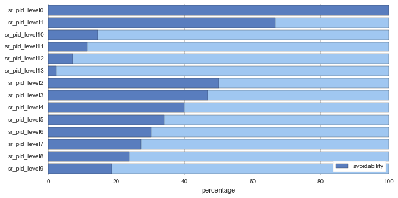

```python
display(df['sr_pid'].notnull().value_counts())
print('Top 20 Products(measured in Total cases raised)')
variable.Bivariate2('sr_pid')
variable.BivariateNP('sr_pid')
variable.Bucketing('sr_pid')
variable.Graph('sr_pid')
variable.MasterSetbucketing('sr_pid')
variable.TestSetbucketing('sr_pid')
```

#### Var 14: Complexity

##### Missing value check & Bi variate analysis

```
True    244294
Name: complexity, dtype: int64
```

```
arma                       complexity  Total_cases  % Cases  Avoidable  \
index
0      3 Level -Exceptionally Complex         6085     0.02        506
1                      1 Level -Basic       122399     0.50       9860
2            UnknownLevel -Procedural        52611     0.22       4214
3                   2 Level -Advanced        62002     0.25       3860
4                                   0         1197     0.00         40

arma   %avoidability
index
0                8.3
1                8.1
2                8.0
3                6.2
4                3.3
```

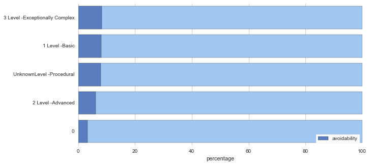

```python
display(df['complexity'].notnull().value_counts())
variable.Bivariate('complexity')
variable.Graph('complexity')
```

#### Var 15: Creator Workgroup Name

##### Missing value check & Bi variate analysis

```
True    244294
Name: creator_workgroup_name, dtype: int64
```

```
Top 20 Creator Workgroups(measured in Total cases raised)
arma creator_workgroup_name  Total_cases  % Cases  Avoidable  %avoidability
0             Not Available       150084    61.44      10706            7.1
1                   SLC-TFL        25488    10.43       2128            8.3
2           ENTITLEMENT-SLC        19304     7.90       1504            7.8
3                  CIN-EEME        12103     4.95       1092            9.0
4               APJ-SYD-GCC         6423     2.63        504            7.8
5                    CIN-CR         5987     2.45        606           10.1
6             APJ-CHINA-GCC         4827     1.98        408            8.5
7                  SLC-HTTS         4419     1.81        449           10.2
8                UNASSIGNED         3631     1.49        284            7.8
9                 JAPAN-GCC         2253     0.92        127            5.6
10            APJ-KOREA-GCC         1291     0.53        123            9.5
11        APJ-CANTONESE-GCC         1194     0.49        103            8.6
12        APJ-CHINA-ENG-GCC         1109     0.45         97            8.7
13                   AMM-SV          498     0.20         74           14.9
14         Licensing-MAN-US          489     0.20          1            0.2
15               APJ-SYD-SR          444     0.18         33            7.4
16              COSENTRY-SV          430     0.18         45           10.5
17             US-DC-SV-RTP          317     0.13         20            6.3
18             JAPAN-UCS-DL          272     0.11         16            5.9
19          LICENSING-CR-US          249     0.10          0            0.0
```

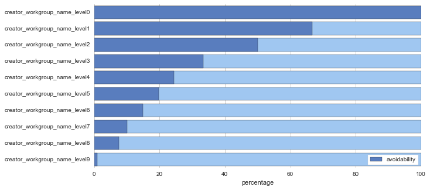

```python
display(df['creator_workgroup_name'].notnull().value_counts())
print('Top 20 Creator Workgroups(measured in Total cases raised)')
variable.Bivariate2('creator_workgroup_name')
variable.BivariateNP('creator_workgroup_name')
variable.Bucketing('creator_workgroup_name')
variable.Graph('creator_workgroup_name')
variable.MasterSetbucketing('creator_workgroup_name')
variable.TestSetbucketing('creator_workgroup_name')
```

#### Var 16: Incident Urgency

##### Missing value check & Bi variate analysis

```
True    244294
Name: incident_urgency, dtype: int64
```

```
arma                                    incident_urgency  Total_cases  \
index
0                                          B2B Escalated         7928
1                                                   NONE       235698
2                             B2B Transferred To Partner          319
3                                            B2B Dormant          324
4                                                      0            2
5                                          Not Escalated            1
6      Queue to Backbone - Customer Requested Escalation            1
7                  Queue to Backbone - Escalated to CAPS            2
8                           SS Transfer from TAC to SSTG           14
9                       Shadow S1 S2 B2B Sr  to  Partner            5

arma   % Cases  Avoidable  %avoidability
index
0         0.03        860           10.8
1         0.96      17579            7.5
2         0.00         21            6.6
3         0.00         20            6.2
4         0.00          0            0.0
5         0.00          0            0.0
6         0.00          0            0.0
7         0.00          0            0.0
8         0.00          0            0.0
9         0.00          0            0.0
```

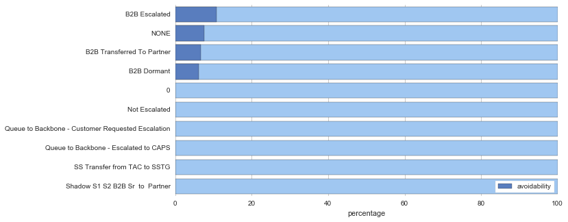

```python
display(df['incident_urgency'].notnull().value_counts())
variable.Bivariate('incident_urgency')
variable.Graph('incident_urgency')
```

#### Var 17: Customer Activity Code

##### Missing value check & Bi variate analysis

```
True    244294
Name: customer_activity_code, dtype: int64
```

```
arma  customer_activity_code  Total_cases  % Cases  Avoidable  %avoidability
index
0                    Unknown        10512     0.04       1057           10.1
1                    OPERATE       119812     0.49      11223            9.4
2                    INSTALL        21771     0.09       1345            6.2
3                     CONFIG        75004     0.31       4240            5.7
4                    UPGRADE        15996     0.07        612            3.8
5                   PLANNING         1199     0.00          3            0.3
```

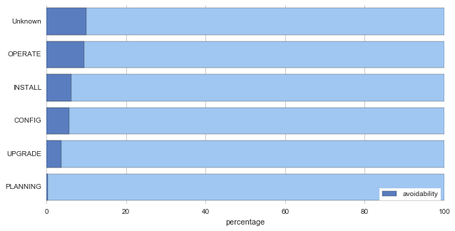

```python
display(df['customer_activity_code'].notnull().value_counts())
variable.Bivariate('customer_activity_code')
variable.Graph('customer_activity_code')
```

#### Var 18: Escalation

##### Missing value check & Bi variate analysis

```
True     238693
False      5601
Name: esc_flag_pm, dtype: int64
```

```
arma  esc_flag_pm  Total_cases  % Cases  Avoidable  %avoidability
index
0               1        13694     0.06       2020           14.8
1               0       224999     0.92      16239            7.2
2         Unknown         5601     0.02        221            3.9
```

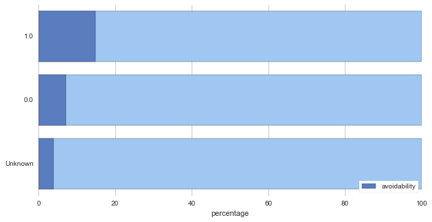

```python
display(df['esc_flag_pm'].notnull().value_counts())
variable.Bivariate('esc_flag_pm')
variable.Graph('esc_flag_pm')
```

### Continuous variables

```python
class Continuous():
    def __init__(self,data):
        self.data = data
        self.varc = list()

    def Bivariate(self,variable):
        self.df = pd.DataFrame()
        self.data[variable].fillna(df[variable].mean(), inplace = True)        # fill missing values
        self.df = pd.crosstab(self.data[variable],self.data.arma.astype(bool))
        self.df.rename(columns={False : 'NonAvoidable', True : 'Avoidable', 'All' : 'Total'}, inplace=True)
        self.df['%avoidability'] = ((self.df['Avoidable'])/(self.df['NonAvoidable'] + self.df['Avoidable']))*100
        self.df['%avoidability'] = self.df['%avoidability'].round(1)
        self.df['Total'] = 100
        self.df['Total_cases']= self.df['NonAvoidable'] + self.df['Avoidable']
        self.df['% Cases']= self.df['Total_cases']/2442.94
        self.df = self.df.sort_values(by = '%avoidability' , axis = 0)
        self.df = self.df.reset_index()
        print(self.df[[variable,'Total_cases','% Cases','%avoidability']])

    def Bivariate2(self,variable):
        self.df = pd.DataFrame()
        self.data[variable].fillna(df[variable].mean(), inplace = True)        # fill missing values
        self.df = pd.crosstab(self.data[variable],self.data.arma.astype(bool))
        self.df.rename(columns={False : 'NonAvoidable', True : 'Avoidable', 'All' : 'Total'}, inplace=True)
        self.df['%avoidability'] = ((self.df['Avoidable'])/(self.df['NonAvoidable'] + self.df['Avoidable']))*100
        self.df['%avoidability'] = self.df['%avoidability'].round(1)
        self.df['Total'] = 100
        self.df['Total_cases']=self.df['NonAvoidable'] + self.df['Avoidable']
        self.df['% Cases']=self.df['Total_cases']/2442.94
        self.df = self.df.sort_values(by = '%avoidability', ascending = False , axis = 0)
        self.df = self.df.reset_index()
        print(self.df[[variable,'Total_cases','% Cases','%avoidability']].head(20))

    def Graph(self,variable):
        self.varc.append(variable)
        sns.set_style("ticks")
        sns.lmplot(variable, '%avoidability', data=self.df, fit_reg=False,scatter_kws={"marker": "D",
                        "s": 100})
        plt.title(variable + ' vs %avoidability')
        plt.xlabel(variable)
        plt.ylabel('%avoidability')

    def Getdata(self):
        return self.data

    def Getvariables(self):
        return self.varc

    def Collinearity(self):
        pass
```

```python
df = variable.Getdata()
display(df['arma'].notnull().value_counts())
variablec = Continuous(df)
```

```
True    244294
Name: arma, dtype: int64
```

#### Var 19: Engineer Count(Dynamic)

- *Description* : Number of Engineers associated with a case
- *Hypothesis* : There is a higher risk of cases having Avoidable RMA when the engineer_cnt is high
- *Findings* :
  - %avoidability increases drasticallty with increase in eng_cnt
  - Cases having more than 11 engineers are always avoidable

##### Missing value check & Bi variate analysis

```
True    244294
Name: engineer_cnt, dtype: int64
```

```
arma  engineer_cnt  Total_cases    % Cases  %avoidability
0                0       158249  64.778095            0.0
1                1        66040  27.033001           16.2
2                2        13213   5.408647           30.8
3                3         3822   1.564508           46.5
4                4         1513   0.619336           56.6
5                5          690   0.282447           65.8
6                6          328   0.134264           73.2
7                7          161   0.065904           78.3
8                9           61   0.024970           80.3
9                8           91   0.037250           82.4
10              10           43   0.017602           88.4
11              11           21   0.008596           95.2
12              22            1   0.000409          100.0
13              35            2   0.000819          100.0
```

[output cut: 16 more lines]

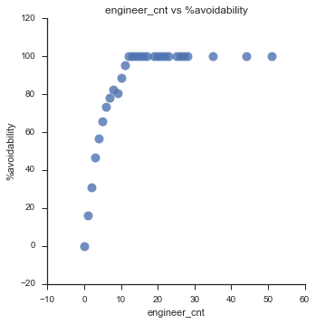

```python
display(df['engineer_cnt'].notnull().value_counts())
variablec.Bivariate('engineer_cnt')
variablec.Graph('engineer_cnt')
```

#### Var 20: Workgroup Count

- *Description* : Number of Workgroups the case got assigned to untils the 1st RMA
- *Hypothesis* : There is a higher risk of cases having ARMA if the Wg_cnt is high
- *Findings* : Cases become highly avoidable(>80%) when work group count goes above 7

##### Missing value check & Bi variate analysis

```
True    244294
Name: wg_cnt, dtype: int64
```

```
arma  wg_cnt  Total_cases    % Cases  %avoidability
0          0       158249  64.778095            0.0
1          1        69188  28.321612           17.1
2          2        12350   5.055384           33.5
3          3         3152   1.290249           50.0
4          4          921   0.377005           62.0
5          5          262   0.107248           71.4
6          6          116   0.047484           78.4
7          8           11   0.004503           90.9
8          7           30   0.012280          100.0
9          9            8   0.003275          100.0
10        10            4   0.001637          100.0
11        13            1   0.000409          100.0
12        14            1   0.000409          100.0
13        15            1   0.000409          100.0
```

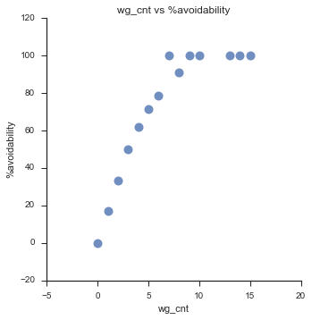

```python
display(df['wg_cnt'].notnull().value_counts())
variablec.Bivariate('wg_cnt')
variablec.Graph('wg_cnt')
```

#### Var 21: Problem Code Count(Dynamic)

- *Description* : Number of problem codes associated to the SR throughout the case ; PCs may or may not change throughout the case
- *Hypothesis* : There is a higher risk of cases having Avoidable RMA if the pc_cnt is high
- *Findings* :
  - % avoidability increases when pc_cnt increases from 2 to 3(increased by 352%) and then from 3 to 4(increased by 70%).
  - ~88% cases were assigned one PC before the 1st RMA

##### Missing value check & Bi variate analysis

```
True    244294
Name: pc_cnt, dtype: int64
```

```
arma  pc_cnt  Total_cases    % Cases  %avoidability
0          5            1   0.000409            0.0
1          1       214356  87.745094            7.0
2          2        29173  11.941759           10.5
3          3          728   0.298002           47.5
4          4           36   0.014736           80.6
```

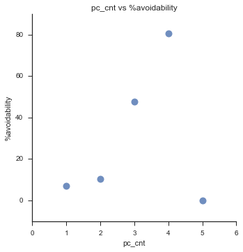

```python
display(df['pc_cnt'].notnull().value_counts())
variablec.Bivariate('pc_cnt')
variablec.Graph('pc_cnt')
```

#### Var 22: SR to LDOS

- *Description* : Number of days between the SR creation date and LDOS; every product has a Last day of Support
- *Hypothesis* : % Avoidability will be higher when SR_to_LDOS is less i.e. when SR is raised close to the LDOS
- *Findings* :

##### Missing value check & Bi variate analysis

```
False    127873
True     116421
Name: sr_to_ldos, dtype: int64
```

```
arma   sr_to_ldos  Total_cases   % Cases  %avoidability
0     1874.535787            1  0.000409          100.0
1      717.301782            1  0.000409          100.0
2     2113.371065            1  0.000409          100.0
3     1055.574225            1  0.000409          100.0
4     2502.052708            1  0.000409          100.0
5     2423.205463            1  0.000409          100.0
6     2597.642870            1  0.000409          100.0
7     2113.415359            1  0.000409          100.0
8     2113.440706            1  0.000409          100.0
9      897.179664            1  0.000409          100.0
10    2502.090891            1  0.000409          100.0
11    2112.052662            1  0.000409          100.0
12    2005.322488            1  0.000409          100.0
13    2423.199514            1  0.000409          100.0
14    2597.448542            1  0.000409          100.0
15    2597.443715            1  0.000409          100.0
16    2165.984861            1  0.000409          100.0
17     897.118194            1  0.000409          100.0
18    2423.184294            1  0.000409          100.0
19    2113.541354            1  0.000409          100.0
```

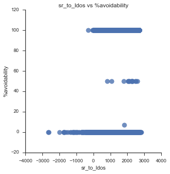

```python
display(df['sr_to_ldos'].notnull().value_counts())
variablec.Bivariate2('sr_to_ldos')
variablec.Graph('sr_to_ldos')
```

#### Var 23: Resolution Code Count

##### Missing value check & Bi variate analysis

```
True    244294
Name: rc_cnt, dtype: int64
```

```
arma  rc_cnt  Total_cases    % Cases  %avoidability
0          0          944   0.386420            2.4
1          1       241932  99.033132            7.5
2          2         1403   0.574308           20.1
3          3           15   0.006140           66.7
```

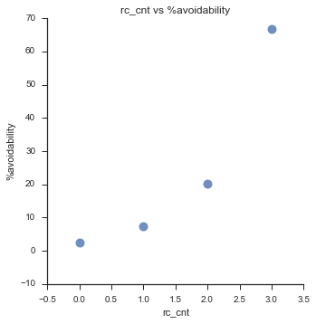

```python
display(df['rc_cnt'].notnull().value_counts())
variablec.Bivariate('rc_cnt')
variablec.Graph('rc_cnt')
```

#### Var 24: Misqueue count

- *Description* : It is the count of requeues when a wrong work group is assigned to the case the Customer raised
- *Hypothesis* : Higher the misqueue_cnt, higher will be the %avoidability
- *Findings* : ~76% of the cases have 0 misqueues; with the increase in misqueue counts, %avoidability increases

##### Missing value check & Bi variate analysis

```
True    244294
Name: misqueue_cnt, dtype: int64
```

```
arma  misqueue_cnt  Total_cases   % Cases  %avoidability
0              150            1  0.000409          100.0
1               34            5  0.002047          100.0
2               55            2  0.000819          100.0
3               26            7  0.002865          100.0
4               27            5  0.002047          100.0
5               28           11  0.004503          100.0
6               29            2  0.000819          100.0
7               30           18  0.007368          100.0
8               54            2  0.000819          100.0
9               33            6  0.002456          100.0
10              35            2  0.000819          100.0
11              52            1  0.000409          100.0
12              36           11  0.004503          100.0
13              37            1  0.000409          100.0
14              38            4  0.001637          100.0
15              39            1  0.000409          100.0
16              40            4  0.001637          100.0
17              42            5  0.002047          100.0
18              44            1  0.000409          100.0
19              45            2  0.000819          100.0
```

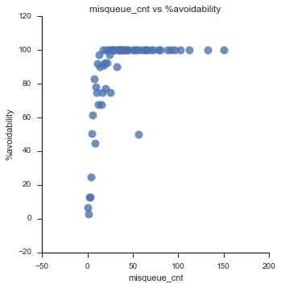

```python
display(df['misqueue_cnt'].notnull().value_counts())
variablec.Bivariate2('misqueue_cnt')
variablec.Graph('misqueue_cnt')
```

#### Var 25: Maximum Severity

##### Missing value check & Bi variate analysis

```
True    244294
Name: max_severity, dtype: int64
```

```
arma  max_severity  Total_cases    % Cases  %avoidability
0                4        12329   5.046788            5.2
1                3       186459  76.325657            6.8
2                2        29474  12.064971           10.6
3                1        16032   6.562584           13.3
```

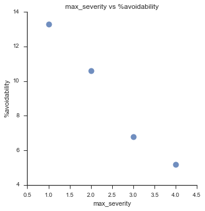

```python
display(df['max_severity'].notnull().value_counts())
variablec.Bivariate('max_severity')
variablec.Graph('max_severity')
```

#### Var 26: Sr Reopened count

##### Missing value check & Bi variate analysis

```
True    244294
Name: sr_reopened_cnt, dtype: int64
```

```
arma  sr_reopened_cnt  Total_cases    % Cases  %avoidability
0                   5            1   0.000409            0.0
1                   0       238511  97.632770            7.2
2                   1         5488   2.246474           23.1
3                   2          272   0.111341           33.1
4                   3           19   0.007778           36.8
5                   4            3   0.001228           66.7
```

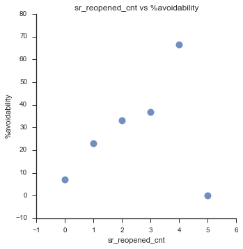

```python
display(df['sr_reopened_cnt'].notnull().value_counts())
variablec.Bivariate('sr_reopened_cnt')
variablec.Graph('sr_reopened_cnt')
```

#### Var 27: Bug Count

##### Missing value check & Bi variate analysis

```
True    244294
Name: bug_cnt, dtype: int64
```

```
arma  bug_cnt  Total_cases    % Cases  %avoidability
0           8            2   0.000819            0.0
1           9            1   0.000409            0.0
2          10            1   0.000409            0.0
3           1        19298   7.899498            5.9
4           0       222292  90.993639            7.7
5           2         2118   0.866988           10.1
6           3          413   0.169059           13.3
7           4          106   0.043390           17.9
8           5           41   0.016783           22.0
9           7            4   0.001637           25.0
10          6           18   0.007368           27.8
```

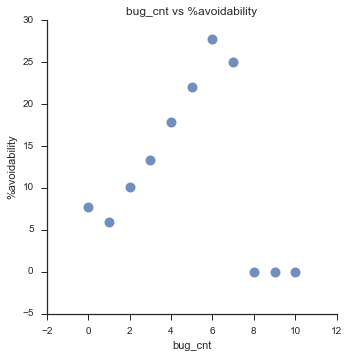

```python
display(df['bug_cnt'].notnull().value_counts())
variablec.Bivariate('bug_cnt')
variablec.Graph('bug_cnt')
```

#### Var 28: RMA rate of a customer

- *Description* : The number of RMAs a customer has raised in the past; based on the recency of the case the RMA counts have been assigned weights. For eg: A case(with 8 RMAs) raised in the FY16Q4 will have RMA count as 8 but A case(with 8 RMAs) raised in the FY15Q4 will have 8*4/8 i.e. 4 RMA count
- *Hypothesis* : There is a higher risk of cases having Avoidable RMA when rma_rate_cust is high
- *Findings* :

##### Missing value check & Bi variate analysis

```
True     227805
False     16489
Name: rma_rate_cust, dtype: int64
```

```
Top 20 rma_rate_cust by %avoidability
arma  rma_rate_cust  Total_cases   % Cases  %avoidability
0            31.000           37  0.015146           27.0
1            17.625           72  0.029473           26.4
2            34.250           58  0.023742           24.1
3            17.000           55  0.022514           23.6
4            58.625           94  0.038478           22.3
5            23.875           51  0.020876           21.6
6           189.500          302  0.123622           21.2
7            19.375           33  0.013508           21.2
8          1248.000         2475  1.013124           20.7
9            40.000           65  0.026607           20.0
10           15.750          105  0.042981           20.0
11           33.375           66  0.027017           19.7
12           30.375           61  0.024970           19.7
13           20.750           33  0.013508           18.2
14           30.500          108  0.044209           17.6
15           60.625          162  0.066314           17.3
16           33.000          128  0.052396           17.2
17           50.000          105  0.042981           17.1
18           54.500          120  0.049121           16.7
19           76.625          121  0.049530           16.5
```

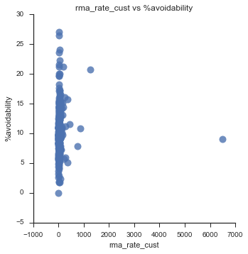

```python
display(df['rma_rate_cust'].notnull().value_counts())
print ('Top 20 rma_rate_cust by %avoidability')
variablec.Bivariate2('rma_rate_cust')
variablec.Graph('rma_rate_cust')
```

#### Var 29: RMA rate of a PID

- *Description* : The number of RMAs raised for a pid in the past; based on the recency of the case the RMA counts have been assigned weights. For eg: A case(with 8 RMAs) raised in the FY16Q4 will have RMA count as 8 but A case(with 8 RMAs) raised in the FY15Q4 will have 8*4/8 i.e. 4 RMA count
- *Hypothesis* : There is a higher risk of cases having Avoidable RMA when rma_rate_pid is high
- *Findings* :

```
True     212597
False     31697
Name: rma_rate_pid, dtype: int64
```

```
Top 20 rma_rate_pid by %avoidability
arma  rma_rate_pid  Total_cases   % Cases  %avoidability
0           17.500           27  0.011052           29.6
1           59.375          104  0.042572           26.9
2           29.375           45  0.018420           26.7
3           43.125           60  0.024561           25.0
4           15.375           16  0.006549           25.0
5           94.875          128  0.052396           25.0
6           47.625           77  0.031519           24.7
7            8.375           43  0.017602           23.3
8           28.125           71  0.029063           22.5
9           18.875           33  0.013508           21.2
10          21.750           38  0.015555           21.1
11         126.875          291  0.119119           21.0
12          27.000           48  0.019648           20.8
13          19.125           64  0.026198           20.3
14          17.375           35  0.014327           20.0
15           8.500           10  0.004093           20.0
16          13.625           31  0.012690           19.4
17          76.125          150  0.061401           19.3
18          35.000           65  0.026607           18.5
19          82.750          169  0.069179           18.3
```

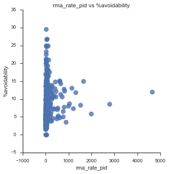

```python
display(df['rma_rate_pid'].notnull().value_counts())
print ('Top 20 rma_rate_pid by %avoidability')
variablec.Bivariate2('rma_rate_pid')
variablec.Graph('rma_rate_pid')
```

#### Var 30: NTF rate of a customer

- *Description* : The number of NTFs associated to a customer in the past; based on the recency of the case the NTF counts have been assigned weights. For eg: A case(with 8 NTFs) raised in the FY16Q4 will have NTF count as 8 but A case(with 8 NTFs) raised in the FY15Q4 will have 8*4/8 i.e. 4 NTF count
- *Hypothesis* : There is a higher risk of cases having Avoidable RMA when ntf_cases_cust is high
- *Findings* :

##### Missing value check & Bi variate analysis

```
True     227805
False     16489
Name: ntf_cases_cust, dtype: int64
```

```
Top 20 ntf_cases_cust by %avoidability
arma  ntf_cases_cust  Total_cases   % Cases  %avoidability
0             62.500         2475  1.013124           20.7
1              4.625          328  0.134264           20.7
2              2.750           90  0.036841           17.8
3             10.000          598  0.244787           16.1
4             51.500         1558  0.637756           15.7
5              8.750          239  0.097833           15.1
6              9.250          391  0.160053           15.1
7              6.625          159  0.065086           14.5
8             10.125          404  0.165375           14.4
9              3.625          182  0.074500           14.3
10             8.875          386  0.158006           14.2
11             3.125          440  0.180111           14.1
12             2.875          438  0.179292           13.9
13             3.750          233  0.095377           12.9
14             5.250          283  0.115844           12.7
15             6.000          163  0.066723           12.3
16             4.250          379  0.155141           11.9
17             2.375          795  0.325428           11.9
18             1.125         2316  0.948038           11.9
19             2.000          323  0.132218           11.8
```

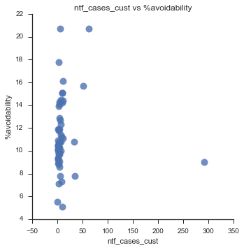

```python
display(df['ntf_cases_cust'].notnull().value_counts())
print ('Top 20 ntf_cases_cust by %avoidability')
variablec.Bivariate2('ntf_cases_cust')
variablec.Graph('ntf_cases_cust')
```

#### Var 31: NTF rate of a PID

- *Description* : The number of NTFs associated to a PID in the past; based on the recency of the case the NTF counts have been assigned weights. For eg: A case(with 8 NTFs) raised in the FY16Q4 will have NTF count as 8 but A case(with 8 NTFs) raised in the FY15Q4 will have 8*4/8 i.e. 4 NTF count
- *Hypothesis* : There is a higher risk of cases having Avoidable RMA when ntf_cases_pid is high
- *Findings* :

##### Missing value check & Bi variate analysis

```
True     212597
False     31697
Name: ntf_cases_pid, dtype: int64
```

```
Top 20 ntf_cases_pid by %avoidability
arma  ntf_cases_pid  Total_cases   % Cases  %avoidability
0             3.875           60  0.024561           25.0
1             5.250          128  0.052396           25.0
2             6.000          221  0.090465           17.2
3             2.500          538  0.220226           15.8
4             3.750          586  0.239875           15.5
5            36.250         1251  0.512088           15.2
6             6.875          960  0.392969           15.0
7            48.250         3328  1.362293           15.0
8            12.625          971  0.397472           14.8
9             4.375          123  0.050349           14.6
10            5.875          896  0.366771           14.3
11            7.250          140  0.057308           13.6
12           73.125         2595  1.062245           13.1
13           18.125          987  0.404021           12.9
14           17.250         1921  0.786348           12.8
15            2.250          681  0.278762           12.8
16            2.375          574  0.234963           12.5
17           14.000         1795  0.734770           12.3
18           15.875         2965  1.213702           12.3
19           28.125         1280  0.523959           12.2
```

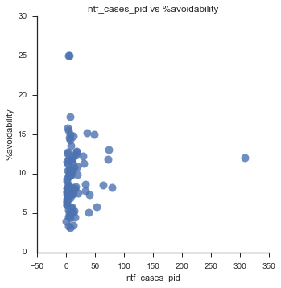

```python
display(df['ntf_cases_pid'].notnull().value_counts())
print ('Top 20 ntf_cases_pid by %avoidability')
variablec.Bivariate2('ntf_cases_pid')
variablec.Graph('ntf_cases_pid')
```